# Prueba_adres_ilich

análisis exploratorio y visualización

2024-02-03 18:18:41.556213

# Data report overview

The dataset examined has the following dimensions:

| Feature | Result |
| --- | --- |
| Number of observations | 504660 |
| Number of variables | 74 |

### Checks performed

The following variable checks were performed, depending on the data type of each variable:

|  | character | factor | labelled | haven labelled | numeric | integer | logical | Date |
| --- | --- | --- | --- | --- | --- | --- | --- | --- |
| Identify miscoded missing values | × | × | × | × | × | × |  | × |
| Identify prefixed and suffixed whitespace | × | × | × | × |  |  |  |  |
| Identify levels with < 6 obs. | × | × | × | × |  |  |  |  |
| Identify case issues | × | × | × | × |  |  |  |  |
| Identify misclassified numeric or integer variables | × | × | × | × |  |  |  |  |
| Identify outliers |  |  |  |  | × | × |  | × |

Please note that all numerical values in the following have been rounded to 2 decimals.

# Summary table

|  | Variable class | # unique values | Missing observations | Any problems? |
| --- | --- | --- | --- | --- |
| ano | numeric | 7 | 0.00 % |  |
| Clase | character | 2 | 0.00 % |  |
| Pertenencia_Etnica | character | 6 | 0.00 % |  |
| Pertenencia_Etnica_Agregada | character | 2 | 0.00 % |  |
| Estrato | character | 7 | 0.00 % |  |
| Colegio_Caracter | character | 2 | 96.48 % | × |
| Region | character | 10 | 5.25 % |  |
| Region_DANE | character | 7 | 5.25 % |  |
| Departamento | character | 34 | 5.25 % |  |
| cod_dpto | numeric | 34 | 5.25 % | × |
| Sexo | character | 2 | 0.00 % |  |
| Grupo_Decenal_Edad | character | 10 | 0.00 % |  |
| Regimen_Afiliacion_p6100 | character | 5 | 6.32 % |  |
| Departamento_Co | character | 34 | 0.00 % |  |
| Quintil_Ingreso_Percapita | character | 5 | 0.00 % |  |
| Quintil_Ingreso_Percapita_Clase | character | 5 | 0.00 % |  |
| fex_c | numeric | 87023 | 0.00 % | × |
| Accion_Tratar_enfermedad_P8563 | character | 9 | 92.70 % |  |
| Accion_Tratar_enfermedad_agregada_P8563 | character | 4 | 92.70 % |  |
| No_Asistencia_Razon_p6153 | character | 14 | 97.49 % |  |
| No_Asistencia_Agregada_p6153 | character | 3 | 97.41 % |  |
| No_Afiliacion_Razon_p768 | character | 9 | 95.15 % |  |
| Dias_incapacidad_p6134 | numeric | 71 | 91.14 % | × |
| Ocupacion_p6240 | character | 7 | 20.22 % |  |
| Ocupacion_Posicion_p6435 | character | 11 | 57.00 % |  |
| Estado_salud_general_P6127 | character | 4 | 0.00 % |  |
| calidad_Atencion_Prevencion_P8595 | character | 5 | 59.67 % |  |
| Enfermedad_Ultimo_mes_P5665 | character | 2 | 0.00 % |  |
| Cubrir_Costos_Atención_Salud_EPS_p8556s1 | character | 3 | 91.14 % |  |
| Cubrir_Costos_Atencion_Salud_Seguro_Voluntario_p8556s2 | character | 3 | 91.14 % |  |
| Cubrir_Costos_Atencion_Salud_Seguro_Obligatorio_p8556s4 | character | 3 | 91.14 % |  |
| Cubrir_Costos_Atencion_Salud_Alcaldia_p8556s5 | character | 3 | 91.14 % |  |
| Cubrir_Costos_Atencion_Salud_Propios_familiares_p8556s6 | character | 3 | 91.14 % |  |
| Cubrir_Costos_Atencion_Salud_Otras_Personas_p8556s9 | character | 3 | 91.14 % |  |
| Cubrir_Costos_Atencion_Salud_No_Requiere_p8556s10 | character | 3 | 91.14 % |  |
| Percepcion_Calidad_Entidad_p6181 | character | 6 | 6.48 % |  |
| Percepcion_Calidad_Entidad_Factor_P798 | character | 8 | 88.02 % |  |
| Percepcion_Calidad_Prestacion_p8554 | logical | 1 | 100.00 % | × |
| Percepcion_Calidad_Prestacion_Factor_P801 | character | 9 | 99.49 % |  |
| Percepcion_pobreza_p5230 | character | 3 | 0.01 % |  |
| Percepcion_suficiencia_ingresos_p9090 | character | 4 | 0.01 % |  |
| Quejas_Ultimo_Ano | character | 3 | 63.57 % |  |
| Tutelas_Ultimo_Ano | character | 3 | 0.01 % |  |
| Tutelas_Ultimo_Ano_razon | character | 8 | 98.42 % |  |
| Cronica_Diagnostico_p1930 | character | 3 | 77.63 % |  |
| Cronica_Tratamiento_p1930s1 | character | 3 | 96.85 % |  |
| Discapacidad_Oir_p1906s1 | character | 5 | 72.38 % |  |
| Consulta_Prevencion_Medico | character | 3 | 57.64 % |  |
| Consulta_Prevencion_Odontologo | character | 3 | 57.64 % |  |
| Consulta_Prevencion_Medico_Odontologo | character | 5 | 42.36 % |  |
| Discapacidad_Hablar_p1906s2 | character | 5 | 72.38 % |  |
| Discapacidad_Ver_p1906s3 | character | 5 | 72.38 % |  |
| Discapacidad_Moverse_Caminar_p1906s4 | character | 5 | 72.38 % |  |
| Discapacidad_Usar_Manos_p1906s5 | character | 5 | 72.38 % |  |
| Discapacidad_Entender_p1906s6 | character | 5 | 72.38 % |  |
| Discapacidad_Comer_Vestirse_Bañarse_Solo_p1906s7 | character | 5 | 72.38 % |  |
| Discapacidad_Relacionarse_p1906s8 | character | 5 | 72.38 % |  |
| Dias_Cita_consulta_Acudio_especialista_p6199 | logical | 1 | 100.00 % | × |
| Dias_Cita_consulta_Medico_p6199 | numeric | 29 | 97.10 % |  |
| Dias_Cita_consulta_Odontologo_p6199 | numeric | 22 | 99.73 % |  |
| Algun_miembro_Hogar_No_Consumio_Ninguna_Comida_Un_Dia_O_Mas_p8706 | character | 3 | 14.71 % |  |
| Controles_Crecimiento_Desarrollo_p6161 | character | 3 | 97.48 % |  |
| Controles_Crecimiento_Desarrollo_numero_p6161 | numeric | 19 | 97.74 % | × |
| Alfabeta_p6160 | character | 3 | 7.62 % |  |
| Asiste_Educacion_p8586 | character | 3 | 7.62 % |  |
| Razon_No_Estudio_p6218 | character | 16 | 77.46 % | × |
| Razon_No_Estudio_Agregada_p6218 | character | 3 | 77.46 % |  |
| Nivel_Educativo_Actual_p8587 | character | 14 | 34.88 % |  |
| Nivel_Educativo_Alcanzado_p1088 | character | 9 | 72.75 % |  |
| Anos_de_Educacion | numeric | 32 | 0.00 % |  |
| Anos_de_Educacion.jefe | numeric | 32 | 0.00 % |  |
| Analfabetismo_IPM | character | 2 | 0.00 % |  |
| Rezago_Escolar_IPM | character | 3 | 79.24 % |  |
| Inasistencia_Escolar_IPM | character | 3 | 79.35 % |  |

# Variable list

## ano

| Feature | Result |
| --- | --- |
| Variable type | numeric |
| Number of missing obs. | 0 (0 %) |
| Number of unique values | 7 |
| Median | 2015 |
| 1st and 3rd quartiles | 2013; 2017 |
| Min. and max. | 2012; 2018 |

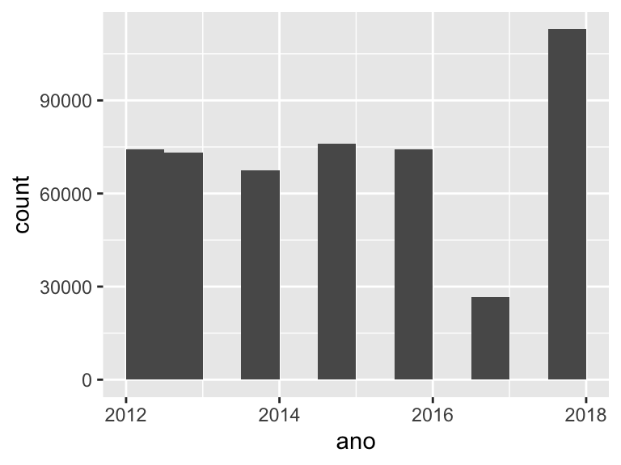

## Clase

| Feature | Result |
| --- | --- |
| Variable type | character |
| Number of missing obs. | 0 (0 %) |
| Number of unique values | 2 |
| Mode | “Cabecera” |

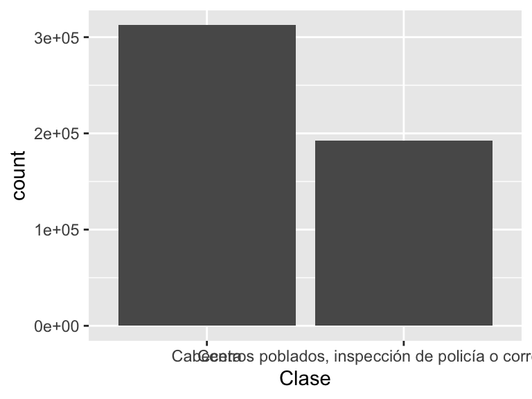

## Pertenencia_Etnica

| Feature | Result |
| --- | --- |
| Variable type | character |
| Number of missing obs. | 0 (0 %) |
| Number of unique values | 6 |
| Mode | “Ninguno de los anteriores” |

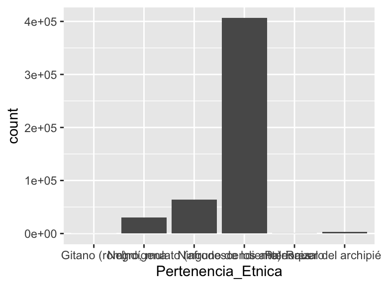

## Pertenencia_Etnica_Agregada

| Feature | Result |
| --- | --- |
| Variable type | character |
| Number of missing obs. | 0 (0 %) |
| Number of unique values | 2 |
| Mode | “Sin Pertenencia étnica” |

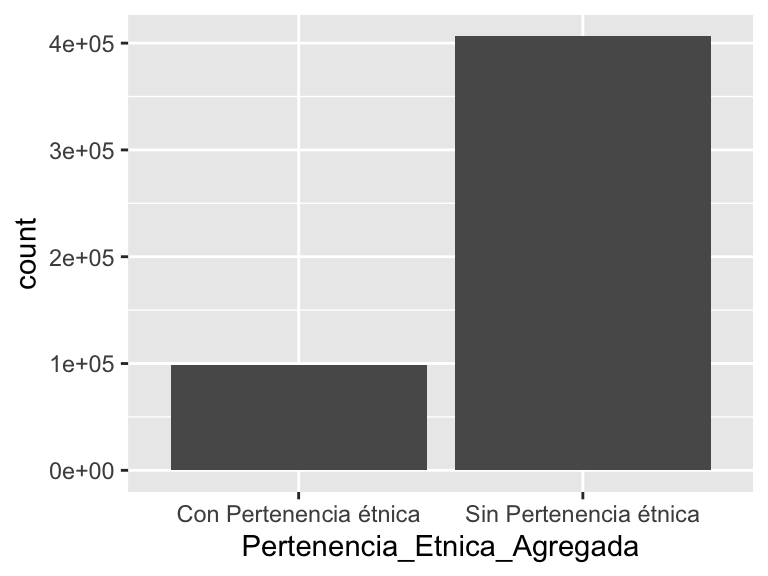

## Estrato

| Feature | Result |
| --- | --- |
| Variable type | character |
| Number of missing obs. | 0 (0 %) |
| Number of unique values | 7 |
| Mode | “1. Bajo - Bajo” |

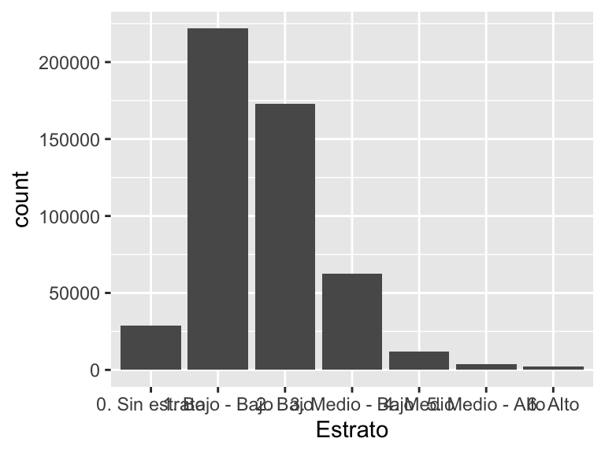

## Colegio_Caracter

- The variable only takes one (non-missing) value: "Oficial". The variable contains 96.48 % missing observations.

## Region

| Feature | Result |
| --- | --- |
| Variable type | character |
| Number of missing obs. | 26500 (5.25 %) |
| Number of unique values | 9 |
| Mode | “Atlántica” |

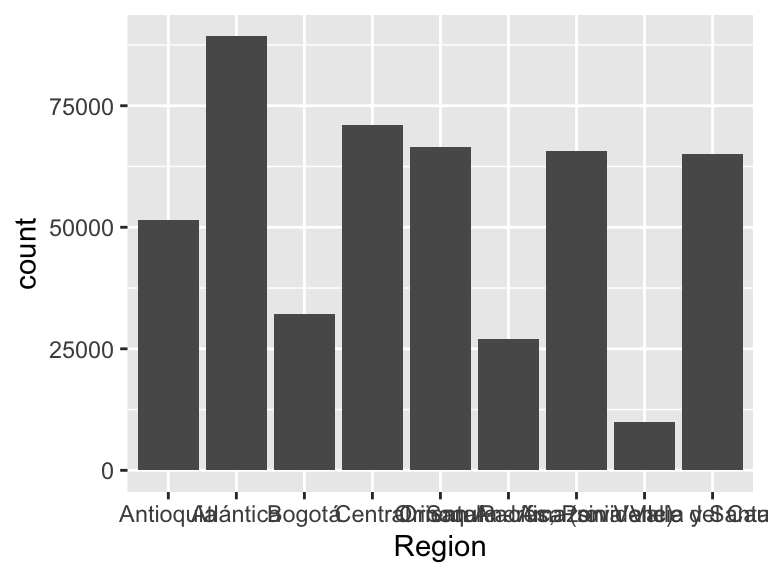

## Region_DANE

| Feature | Result |
| --- | --- |
| Variable type | character |
| Number of missing obs. | 26500 (5.25 %) |
| Number of unique values | 6 |
| Mode | “Pacífica” |

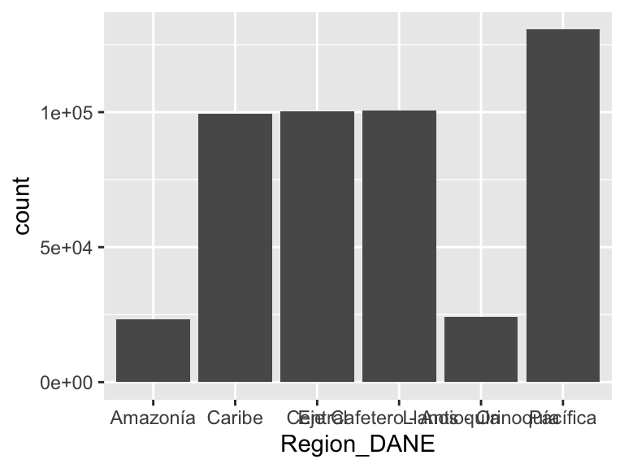

## Departamento

| Feature | Result |
| --- | --- |
| Variable type | character |
| Number of missing obs. | 26500 (5.25 %) |
| Number of unique values | 33 |
| Mode | “Valle del Cauca” |

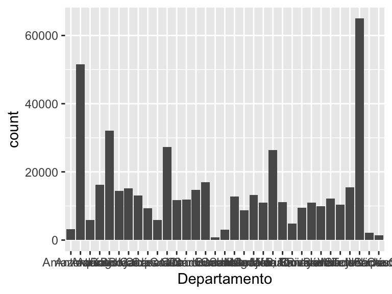

## cod_dpto

| Feature | Result |
| --- | --- |
| Variable type | numeric |
| Number of missing obs. | 26500 (5.25 %) |
| Number of unique values | 33 |
| Median | 41 |
| 1st and 3rd quartiles | 15; 70 |
| Min. and max. | 5; 99 |

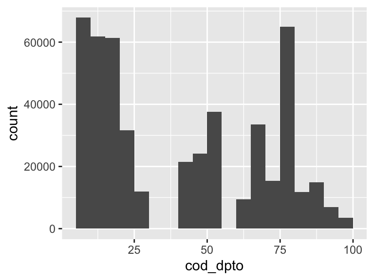

- The following suspected missing value codes enter as regular values: "99".

## Sexo

| Feature | Result |
| --- | --- |
| Variable type | character |
| Number of missing obs. | 0 (0 %) |
| Number of unique values | 2 |
| Mode | “Mujer” |

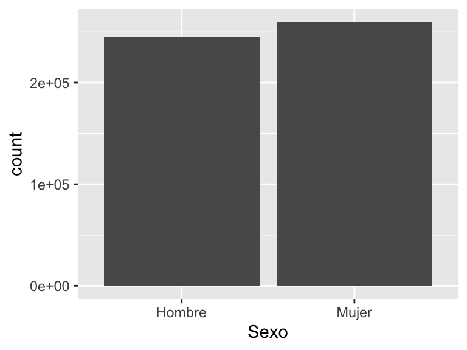

## Grupo_Decenal_Edad

| Feature | Result |
| --- | --- |
| Variable type | character |
| Number of missing obs. | 0 (0 %) |
| Number of unique values | 10 |
| Mode | “[10,20)” |

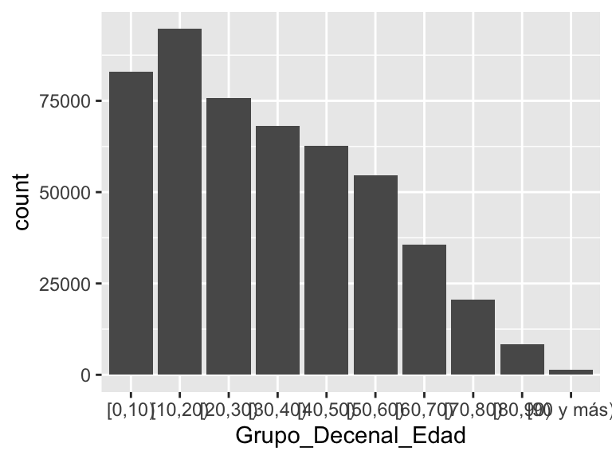

## Regimen_Afiliacion_p6100

| Feature | Result |
| --- | --- |
| Variable type | character |
| Number of missing obs. | 31875 (6.32 %) |
| Number of unique values | 4 |
| Mode | “2. Subsidiado (eps-s)” |

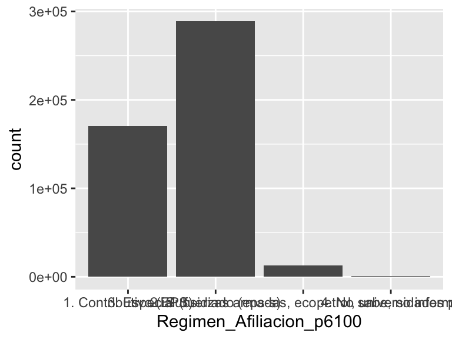

## Departamento_Co

| Feature | Result |
| --- | --- |
| Variable type | character |
| Number of missing obs. | 0 (0 %) |
| Number of unique values | 34 |
| Mode | “Valle del Cauca Colombia” |

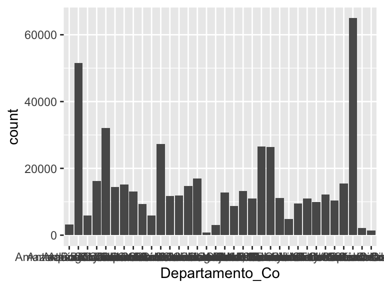

## Quintil_Ingreso_Percapita

| Feature | Result |
| --- | --- |
| Variable type | character |
| Number of missing obs. | 0 (0 %) |
| Number of unique values | 5 |
| Mode | “Quintil 4” |

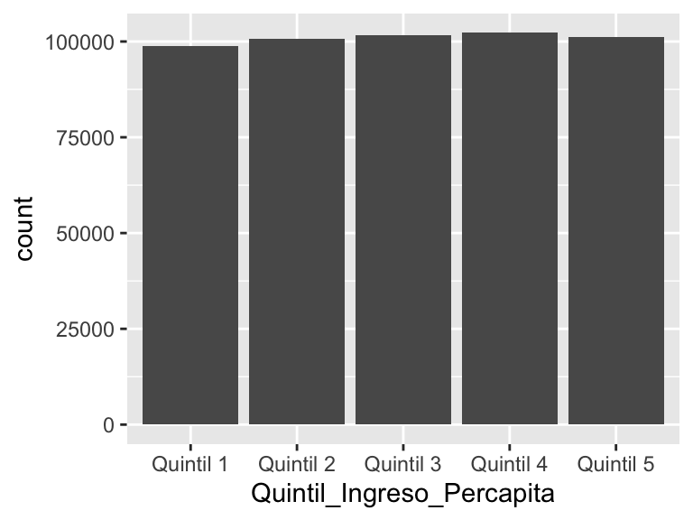

## Quintil_Ingreso_Percapita_Clase

| Feature | Result |
| --- | --- |
| Variable type | character |
| Number of missing obs. | 0 (0 %) |
| Number of unique values | 5 |
| Mode | “Quintil 2” |

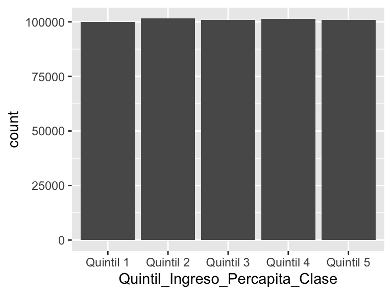

## fex_c

| Feature | Result |
| --- | --- |
| Variable type | numeric |
| Number of missing obs. | 0 (0 %) |
| Number of unique values | 87023 |
| Median | 343.03 |
| 1st and 3rd quartiles | 151.07; 747.89 |
| Min. and max. | 2.43; 9401.79 |

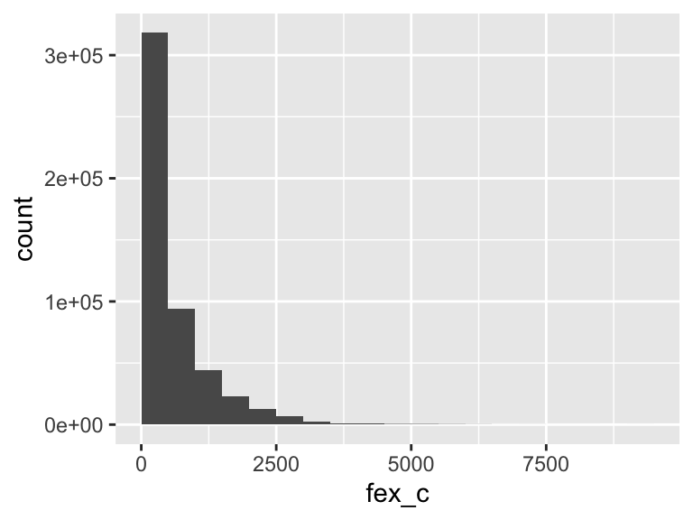

- Note that the following possible outlier values were detected: "4086.63", "4092.87", "4095.38", "4113.64", "4113.96", …, "7391.16", "7682.32", "7860.04", "8008.04", "9401.79" (268 values omitted).

## Accion_Tratar_enfermedad_P8563

| Feature | Result |
| --- | --- |
| Variable type | character |
| Number of missing obs. | 467811 (92.7 %) |
| Number of unique values | 8 |
| Mode | “Acudió a Institución prestadora de servicios de salud” |

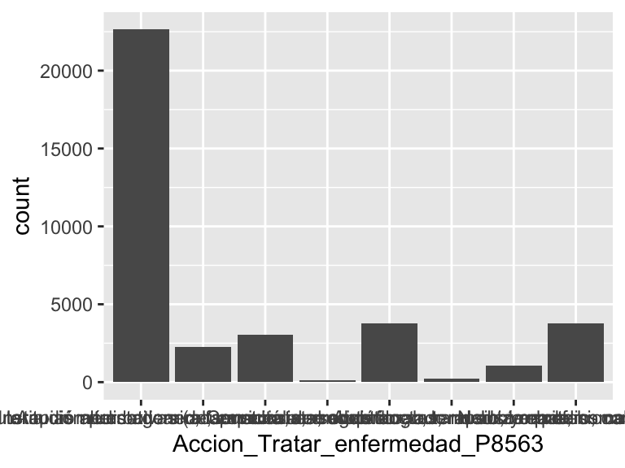

## Accion_Tratar_enfermedad_agregada_P8563

| Feature | Result |
| --- | --- |
| Variable type | character |
| Number of missing obs. | 467811 (92.7 %) |
| Number of unique values | 3 |
| Mode | “Médica Profesional” |

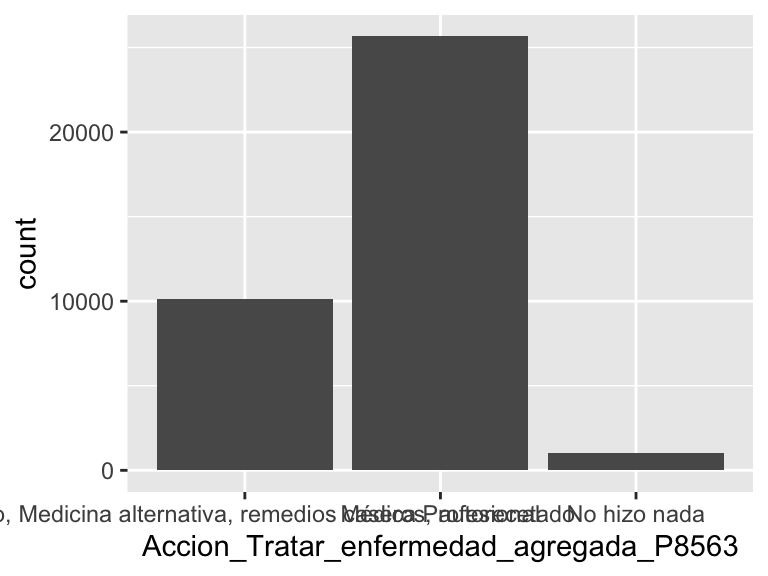

## No_Asistencia_Razon_p6153

| Feature | Result |
| --- | --- |
| Variable type | character |
| Number of missing obs. | 491980 (97.49 %) |
| Number of unique values | 13 |
| Mode | “Caso leve” |

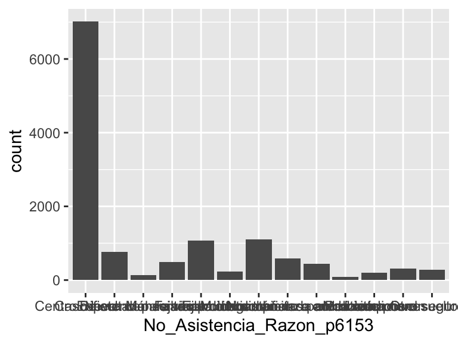

## No_Asistencia_Agregada_p6153

| Feature | Result |
| --- | --- |
| Variable type | character |
| Number of missing obs. | 491569 (97.41 %) |
| Number of unique values | 2 |
| Mode | “Demanda” |

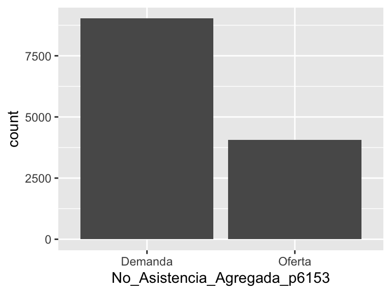

## No_Afiliacion_Razon_p768

| Feature | Result |
| --- | --- |
| Variable type | character |
| Number of missing obs. | 480195 (95.15 %) |
| Number of unique values | 8 |
| Mode | “Afiliación en trámite” |

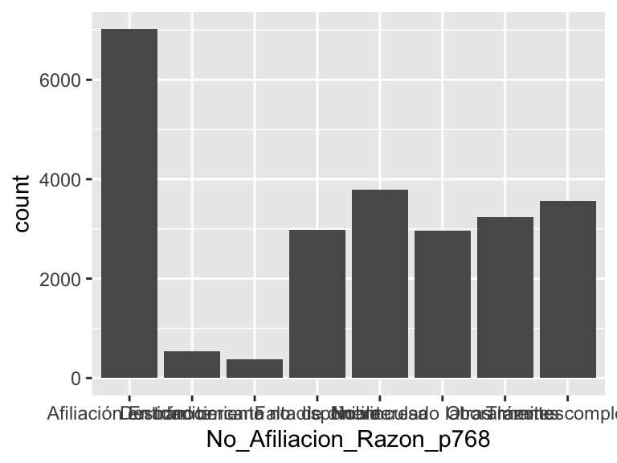

## Dias_incapacidad_p6134

| Feature | Result |
| --- | --- |
| Variable type | numeric |
| Number of missing obs. | 459922 (91.14 %) |
| Number of unique values | 70 |
| Median | 2 |
| 1st and 3rd quartiles | 0; 7 |
| Min. and max. | 0; 120 |

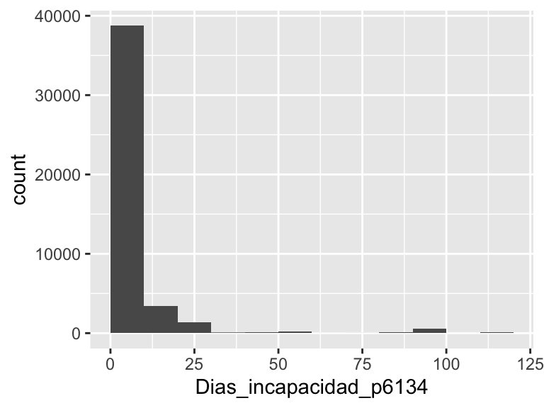

- Note that the following possible outlier values were detected: "55", "56", "58", "60", "67", …, "105", "110", "112", "119", "120" (12 values omitted).

## Ocupacion_p6240

| Feature | Result |
| --- | --- |
| Variable type | character |
| Number of missing obs. | 102042 (20.22 %) |
| Number of unique values | 6 |
| Mode | “Trabajando” |

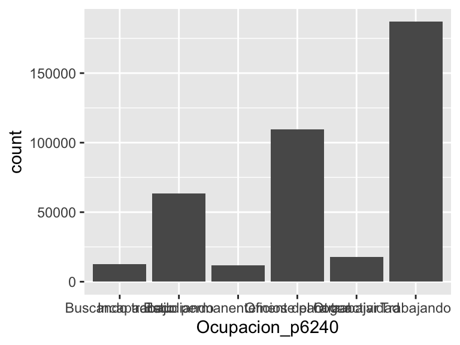

## Ocupacion_Posicion_p6435

| Feature | Result |
| --- | --- |
| Variable type | character |
| Number of missing obs. | 287670 (57 %) |
| Number of unique values | 10 |
| Mode | “Trabajador independiente o por cuenta propia” |

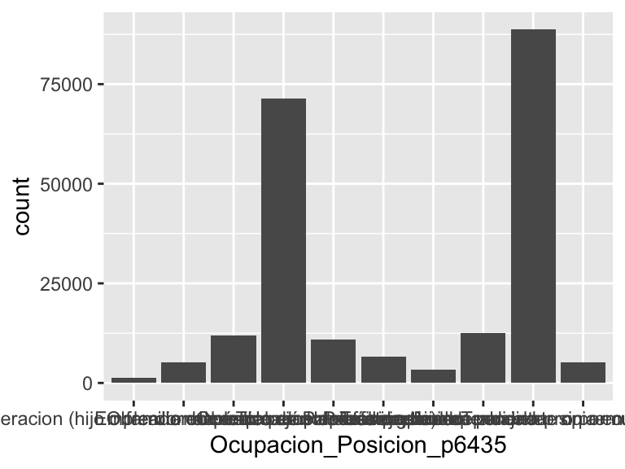

## Estado_salud_general_P6127

| Feature | Result |
| --- | --- |
| Variable type | character |
| Number of missing obs. | 0 (0 %) |
| Number of unique values | 4 |
| Mode | “2. Bueno” |

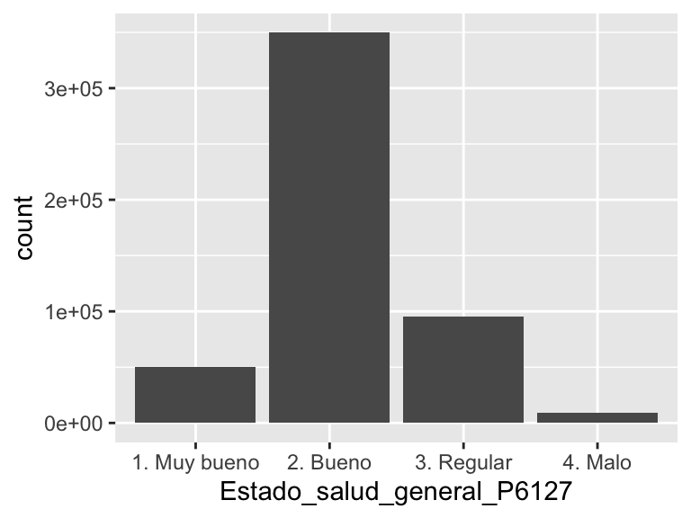

## calidad_Atencion_Prevencion_P8595

| Feature | Result |
| --- | --- |
| Variable type | character |
| Number of missing obs. | 301123 (59.67 %) |
| Number of unique values | 4 |
| Mode | “Buena” |

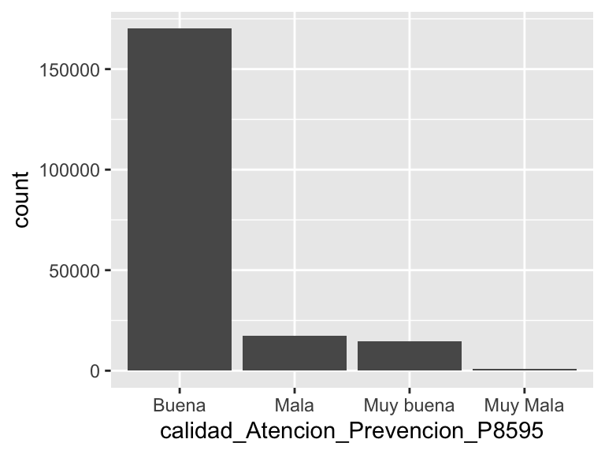

## Enfermedad_Ultimo_mes_P5665

| Feature | Result |
| --- | --- |
| Variable type | character |
| Number of missing obs. | 0 (0 %) |
| Number of unique values | 2 |
| Mode | “No” |

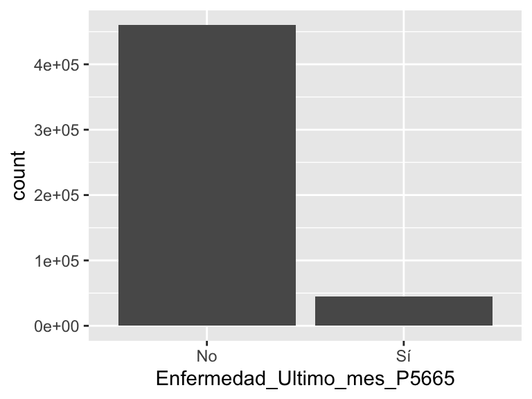

## Cubrir_Costos_Atención_Salud_EPS_p8556s1

| Feature | Result |
| --- | --- |
| Variable type | character |
| Number of missing obs. | 459922 (91.14 %) |
| Number of unique values | 2 |
| Mode | “Entidad de seguridad social de la cual es afiliado” |

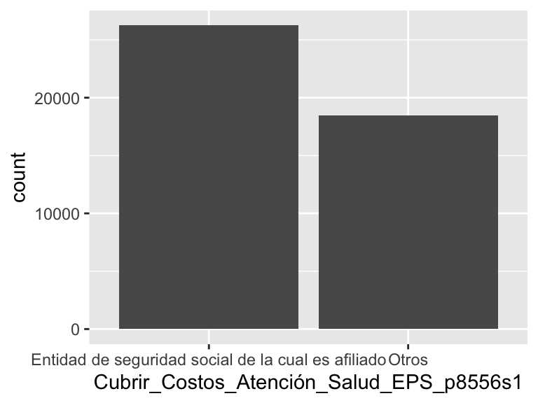

## Cubrir_Costos_Atencion_Salud_Seguro_Voluntario_p8556s2

| Feature | Result |
| --- | --- |
| Variable type | character |
| Number of missing obs. | 459922 (91.14 %) |
| Number of unique values | 2 |
| Mode | “Otros” |

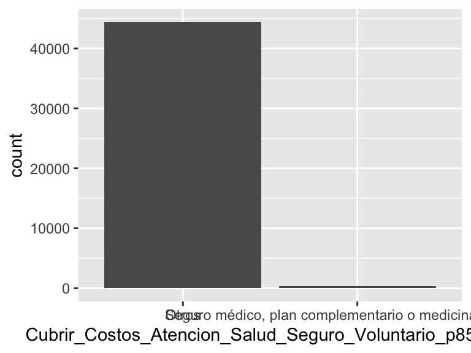

## Cubrir_Costos_Atencion_Salud_Seguro_Obligatorio_p8556s4

| Feature | Result |
| --- | --- |
| Variable type | character |
| Number of missing obs. | 459922 (91.14 %) |
| Number of unique values | 2 |
| Mode | “Otros” |

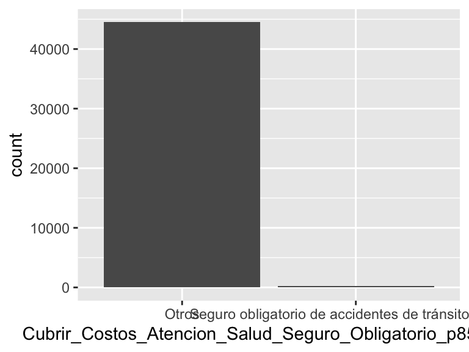

## Cubrir_Costos_Atencion_Salud_Alcaldia_p8556s5

| Feature | Result |
| --- | --- |
| Variable type | character |
| Number of missing obs. | 459922 (91.14 %) |
| Number of unique values | 2 |
| Mode | “Otros” |

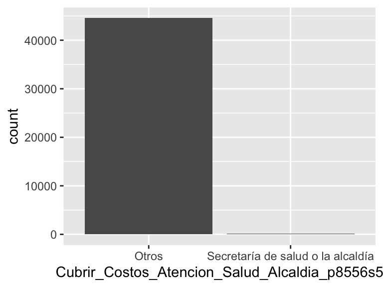

## Cubrir_Costos_Atencion_Salud_Propios_familiares_p8556s6

| Feature | Result |
| --- | --- |
| Variable type | character |
| Number of missing obs. | 459922 (91.14 %) |
| Number of unique values | 2 |
| Mode | “Otros” |

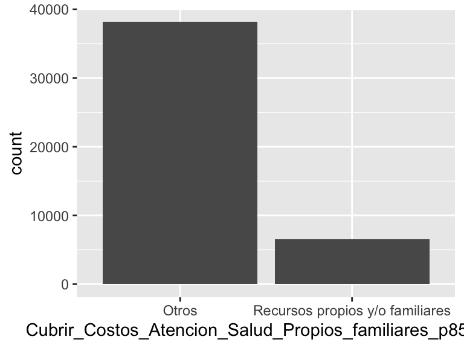

## Cubrir_Costos_Atencion_Salud_Otras_Personas_p8556s9

| Feature | Result |
| --- | --- |
| Variable type | character |
| Number of missing obs. | 459922 (91.14 %) |
| Number of unique values | 2 |
| Mode | “Otros” |

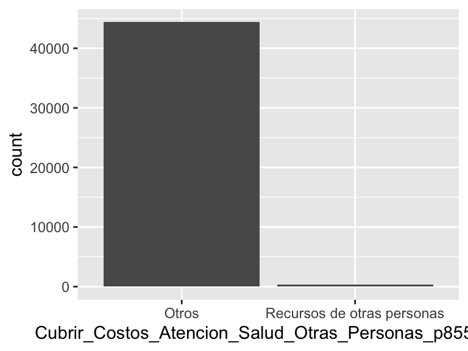

## Cubrir_Costos_Atencion_Salud_No_Requiere_p8556s10

| Feature | Result |
| --- | --- |
| Variable type | character |
| Number of missing obs. | 459922 (91.14 %) |
| Number of unique values | 2 |
| Mode | “Otros” |

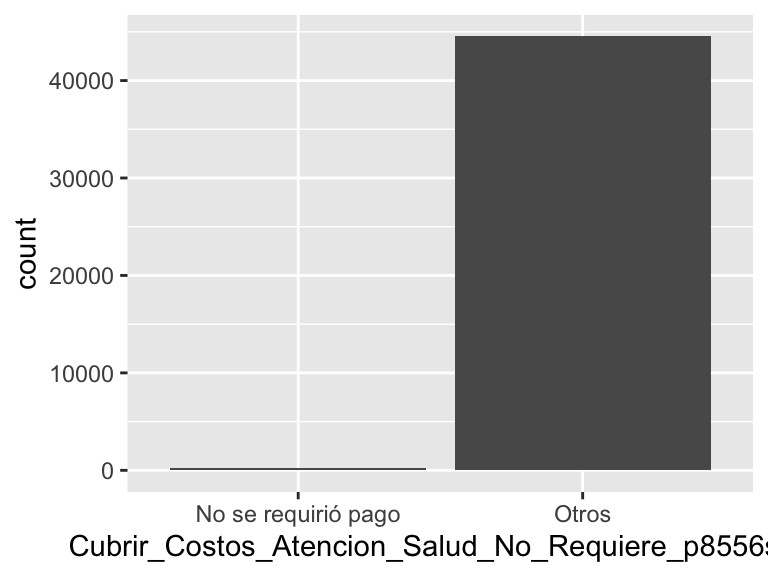

## Percepcion_Calidad_Entidad_p6181

| Feature | Result |
| --- | --- |
| Variable type | character |
| Number of missing obs. | 32718 (6.48 %) |
| Number of unique values | 5 |
| Mode | “2. Bueno” |

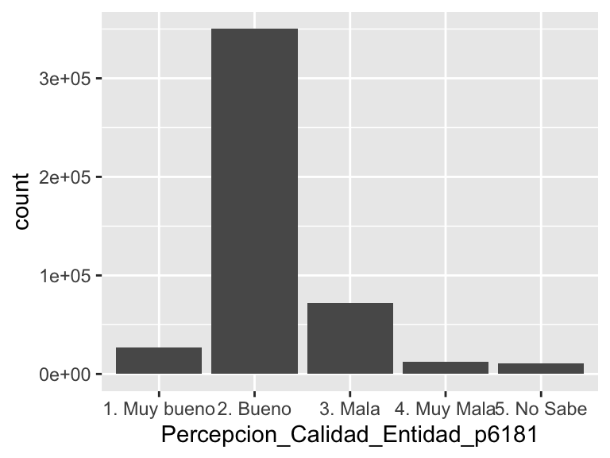

## Percepcion_Calidad_Entidad_Factor_P798

| Feature | Result |
| --- | --- |
| Variable type | character |
| Number of missing obs. | 444192 (88.02 %) |
| Number of unique values | 7 |
| Mode | “Demora en citas” |

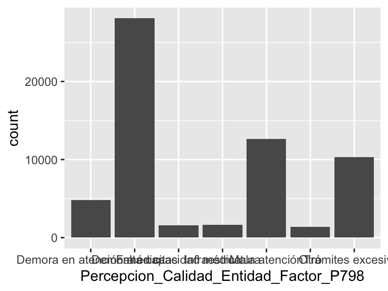

## Percepcion_Calidad_Prestacion_p8554

- The variable only takes one value: "NA".

## Percepcion_Calidad_Prestacion_Factor_P801

| Feature | Result |
| --- | --- |
| Variable type | character |
| Number of missing obs. | 502075 (99.49 %) |
| Number of unique values | 8 |
| Mode | “Mala atención del personal administrativo o asistencial (méd” |

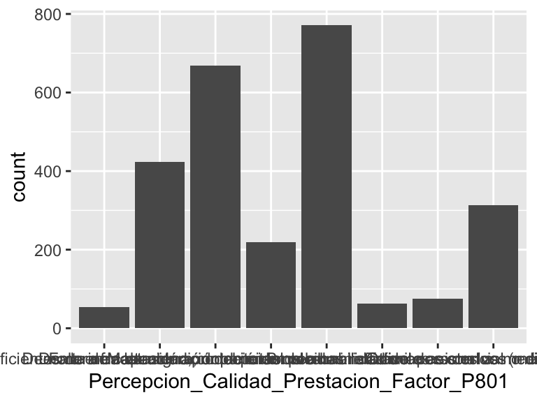

## Percepcion_pobreza_p5230

| Feature | Result |
| --- | --- |
| Variable type | character |
| Number of missing obs. | 73 (0.01 %) |
| Number of unique values | 2 |
| Mode | “No” |

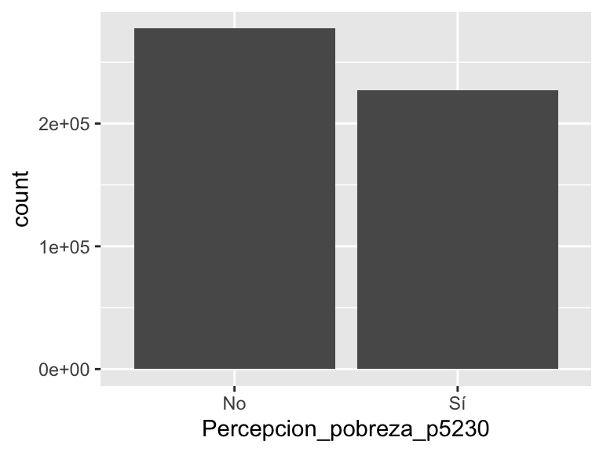

## Percepcion_suficiencia_ingresos_p9090

| Feature | Result |
| --- | --- |
| Variable type | character |
| Number of missing obs. | 73 (0.01 %) |
| Number of unique values | 3 |
| Mode | “Alcanza para cubrir gastos mínimos” |

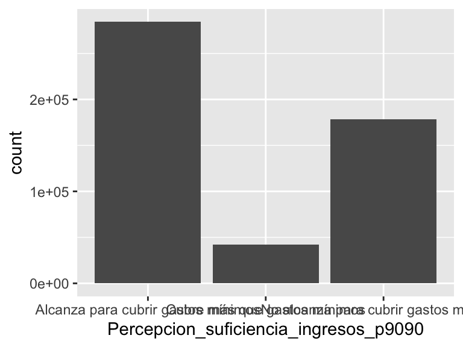

## Quejas_Ultimo_Ano

| Feature | Result |
| --- | --- |
| Variable type | character |
| Number of missing obs. | 320834 (63.57 %) |
| Number of unique values | 2 |
| Mode | “No” |

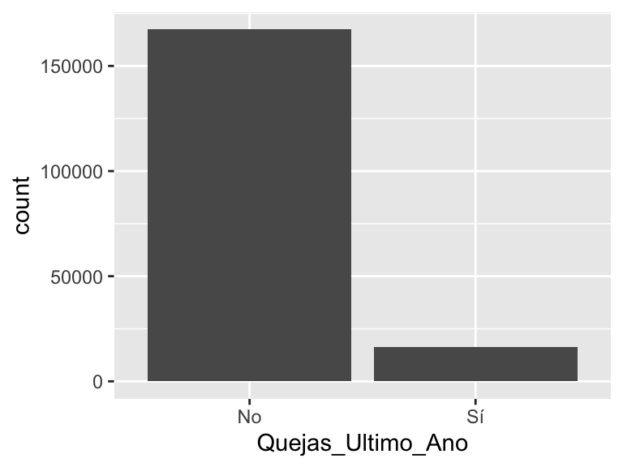

## Tutelas_Ultimo_Ano

| Feature | Result |
| --- | --- |
| Variable type | character |
| Number of missing obs. | 73 (0.01 %) |
| Number of unique values | 2 |
| Mode | “No” |

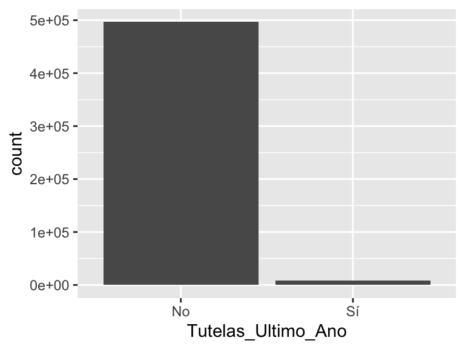

## Tutelas_Ultimo_Ano_razon

| Feature | Result |
| --- | --- |
| Variable type | character |
| Number of missing obs. | 496664 (98.42 %) |
| Number of unique values | 7 |
| Mode | “No lo atendieron en una institución de salud” |

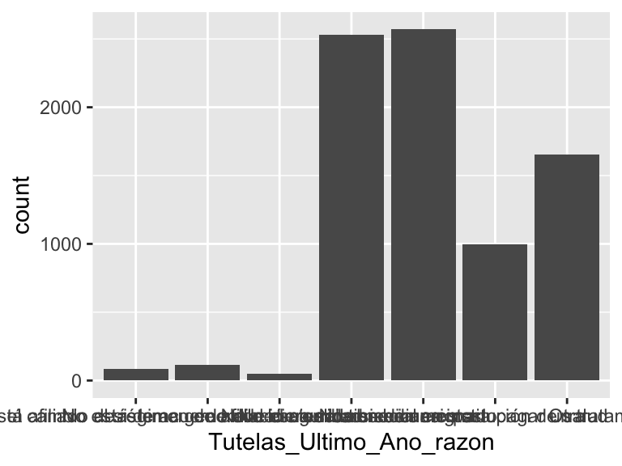

## Cronica_Diagnostico_p1930

| Feature | Result |
| --- | --- |
| Variable type | character |
| Number of missing obs. | 391750 (77.63 %) |
| Number of unique values | 2 |
| Mode | “No” |

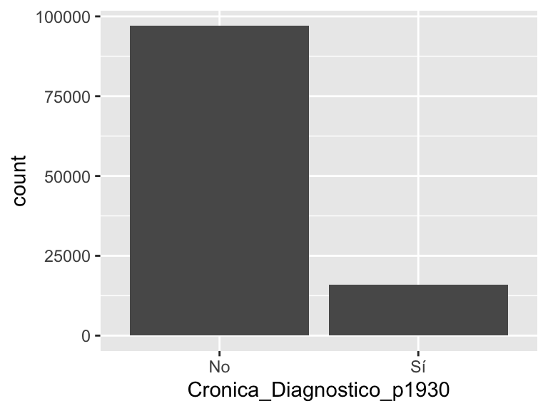

## Cronica_Tratamiento_p1930s1

| Feature | Result |
| --- | --- |
| Variable type | character |
| Number of missing obs. | 488762 (96.85 %) |
| Number of unique values | 2 |
| Mode | “Sí” |

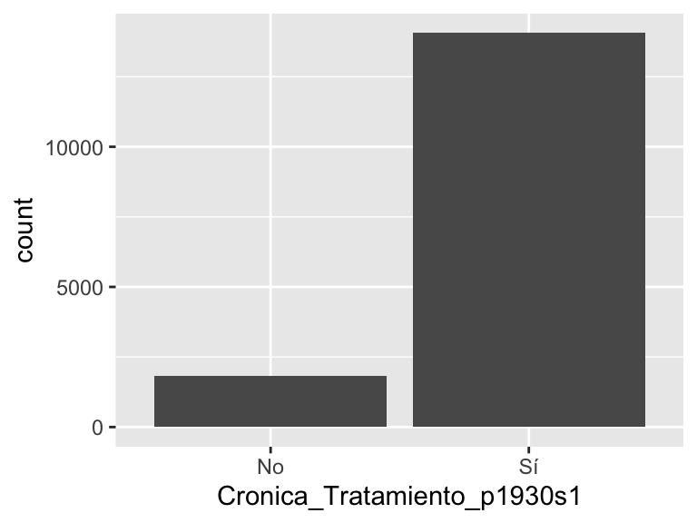

## Discapacidad_Oir_p1906s1

| Feature | Result |
| --- | --- |
| Variable type | character |
| Number of missing obs. | 365250 (72.38 %) |
| Number of unique values | 4 |
| Mode | “Sin dificultad” |

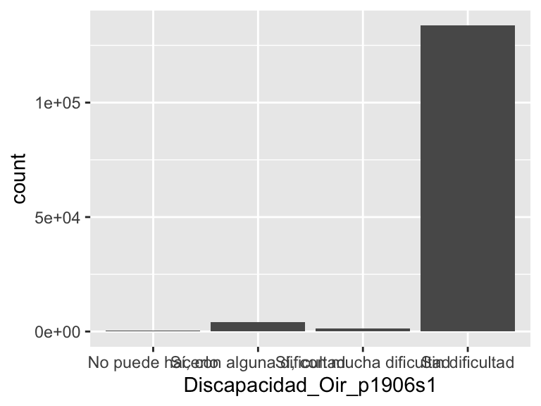

## Consulta_Prevencion_Medico

| Feature | Result |
| --- | --- |
| Variable type | character |
| Number of missing obs. | 290901 (57.64 %) |
| Number of unique values | 2 |
| Mode | “Si” |

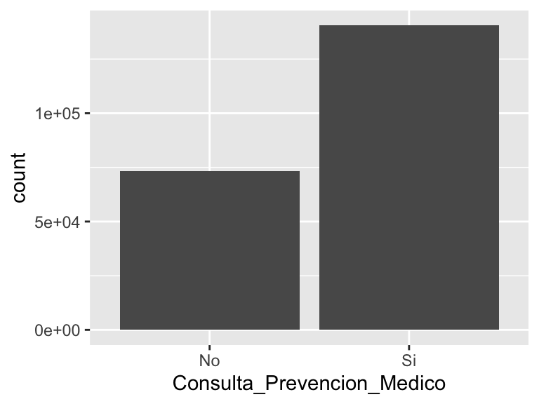

## Consulta_Prevencion_Odontologo

| Feature | Result |
| --- | --- |
| Variable type | character |
| Number of missing obs. | 290901 (57.64 %) |
| Number of unique values | 2 |
| Mode | “Si” |

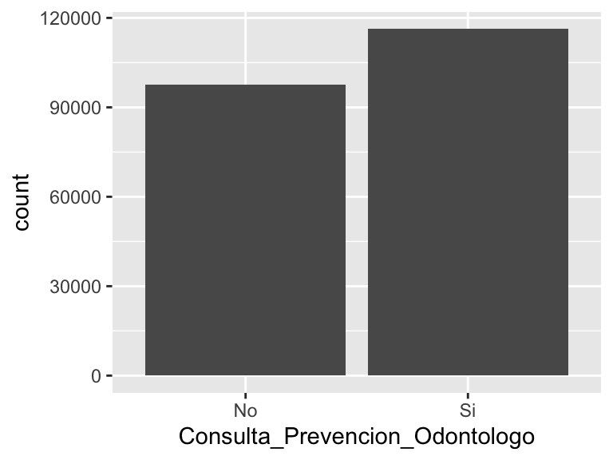

## Consulta_Prevencion_Medico_Odontologo

| Feature | Result |
| --- | --- |
| Variable type | character |
| Number of missing obs. | 213759 (42.36 %) |
| Number of unique values | 4 |
| Mode | “Al médico y al odontólogo” |

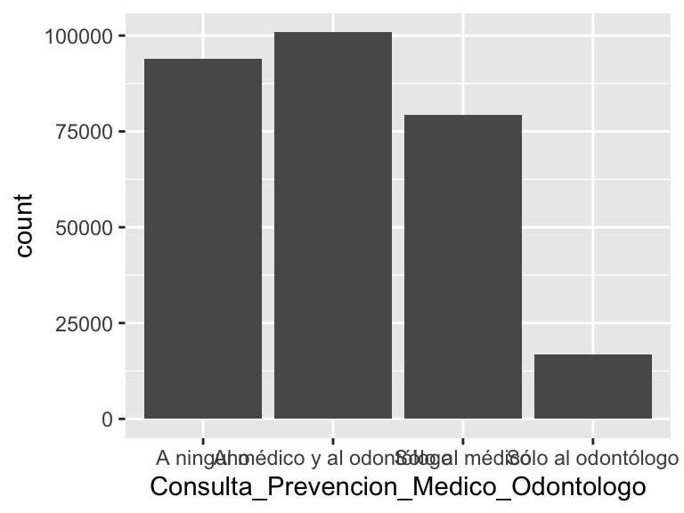

## Discapacidad_Hablar_p1906s2

| Feature | Result |
| --- | --- |
| Variable type | character |
| Number of missing obs. | 365250 (72.38 %) |
| Number of unique values | 4 |
| Mode | “Sin dificultad” |

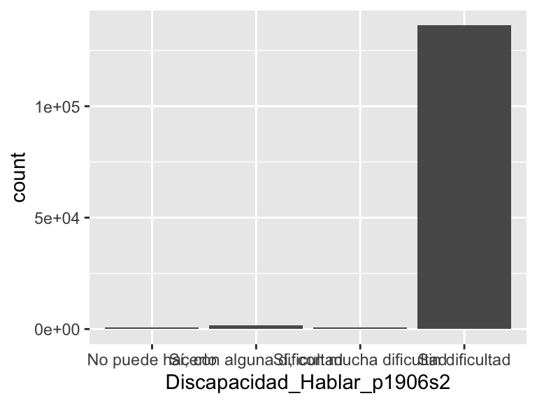

## Discapacidad_Ver_p1906s3

| Feature | Result |
| --- | --- |
| Variable type | character |
| Number of missing obs. | 365250 (72.38 %) |
| Number of unique values | 4 |
| Mode | “Sin dificultad” |

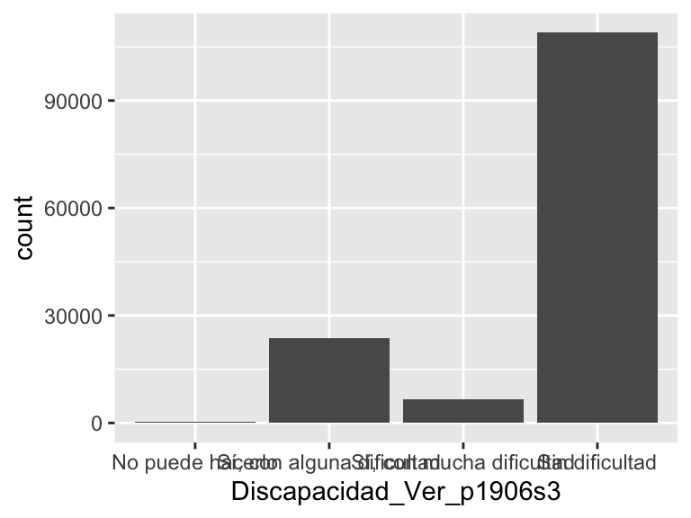

## Discapacidad_Moverse_Caminar_p1906s4

| Feature | Result |
| --- | --- |
| Variable type | character |
| Number of missing obs. | 365250 (72.38 %) |
| Number of unique values | 4 |
| Mode | “Sin dificultad” |

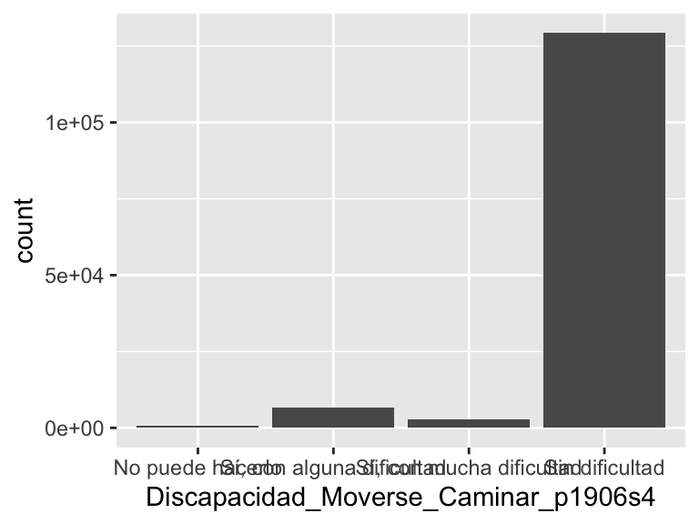

## Discapacidad_Usar_Manos_p1906s5

| Feature | Result |
| --- | --- |
| Variable type | character |
| Number of missing obs. | 365250 (72.38 %) |
| Number of unique values | 4 |
| Mode | “Sin dificultad” |

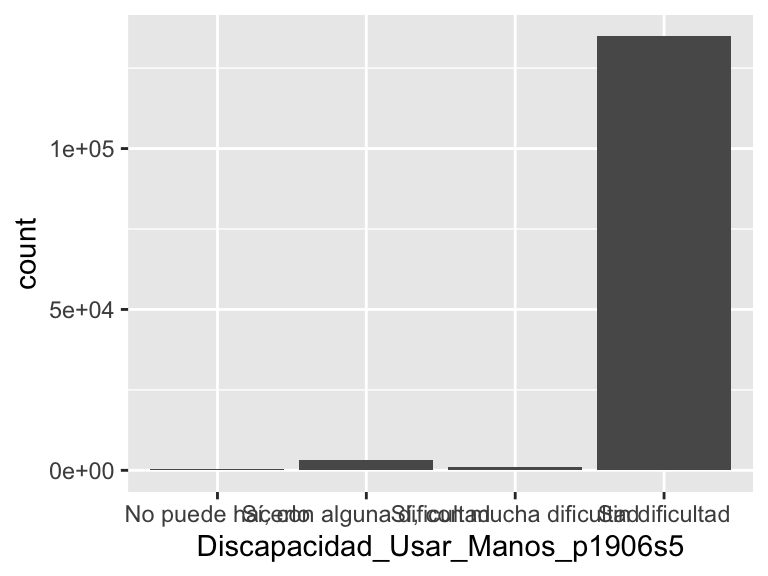

## Discapacidad_Entender_p1906s6

| Feature | Result |
| --- | --- |
| Variable type | character |
| Number of missing obs. | 365250 (72.38 %) |
| Number of unique values | 4 |
| Mode | “Sin dificultad” |

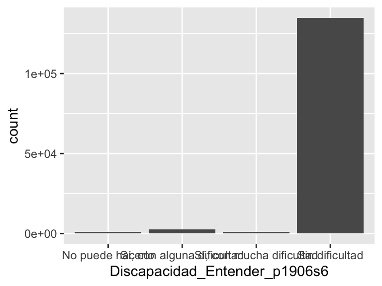

## Discapacidad_Comer_Vestirse_Bañarse_Solo_p1906s7

| Feature | Result |
| --- | --- |
| Variable type | character |
| Number of missing obs. | 365250 (72.38 %) |
| Number of unique values | 4 |
| Mode | “Sin dificultad” |

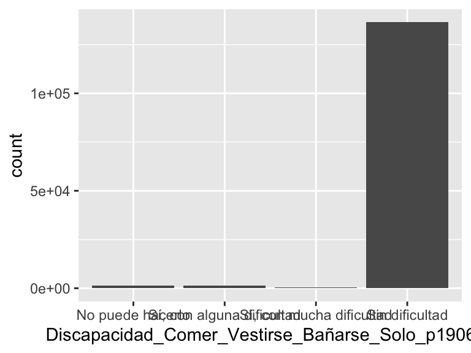

## Discapacidad_Relacionarse_p1906s8

| Feature | Result |
| --- | --- |
| Variable type | character |
| Number of missing obs. | 365250 (72.38 %) |
| Number of unique values | 4 |
| Mode | “Sin dificultad” |

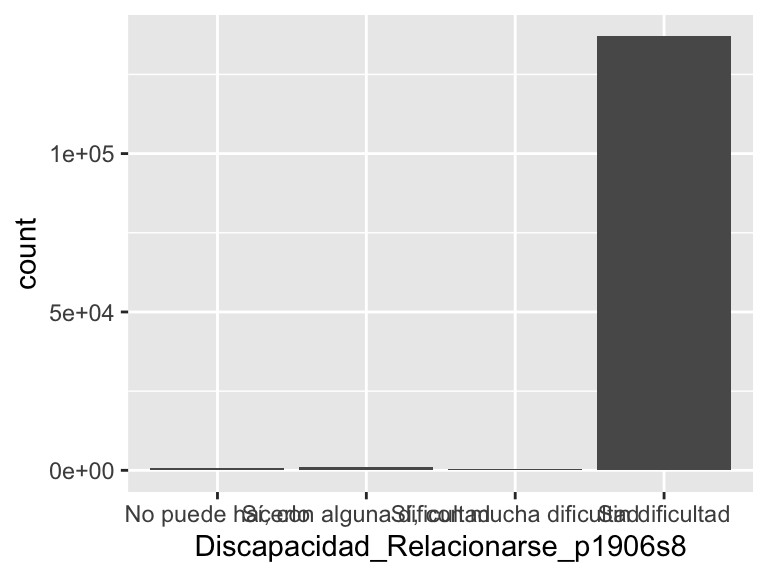

## Dias_Cita_consulta_Acudio_especialista_p6199

- The variable only takes one value: "NA".

## Dias_Cita_consulta_Medico_p6199

| Feature | Result |
| --- | --- |
| Variable type | numeric |
| Number of missing obs. | 490020 (97.1 %) |
| Number of unique values | 28 |
| Median | 1 |
| 1st and 3rd quartiles | 0; 3 |
| Min. and max. | 0; 30 |

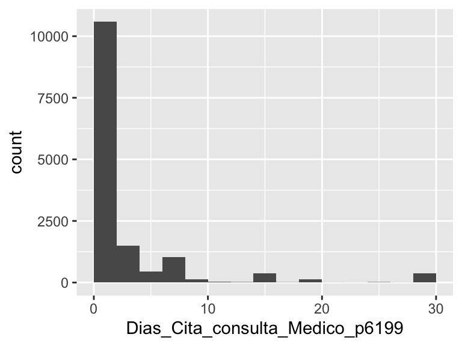

## Dias_Cita_consulta_Odontologo_p6199

| Feature | Result |
| --- | --- |
| Variable type | numeric |
| Number of missing obs. | 503313 (99.73 %) |
| Number of unique values | 21 |
| Median | 1 |
| 1st and 3rd quartiles | 0; 3 |
| Min. and max. | 0; 30 |

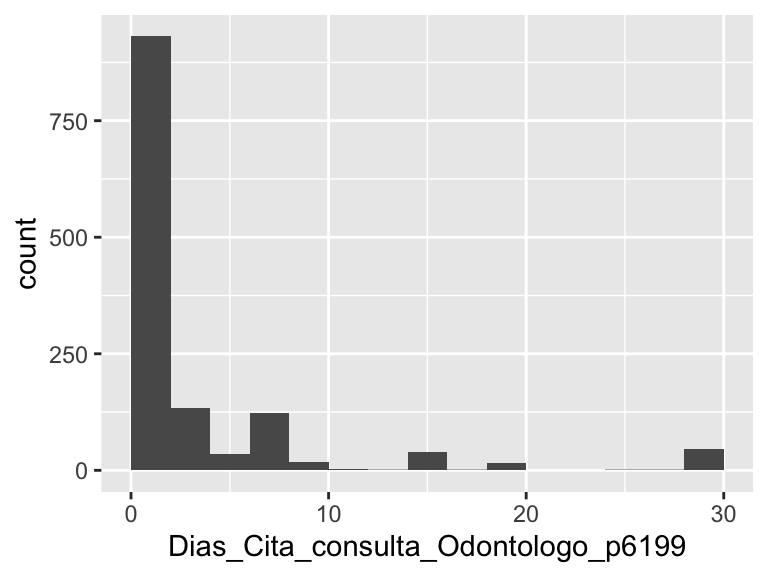

## Algun_miembro_Hogar_No_Consumio_Ninguna_Comida_Un_Dia_O_Mas_p8706

| Feature | Result |
| --- | --- |
| Variable type | character |
| Number of missing obs. | 74240 (14.71 %) |
| Number of unique values | 2 |
| Mode | “No” |

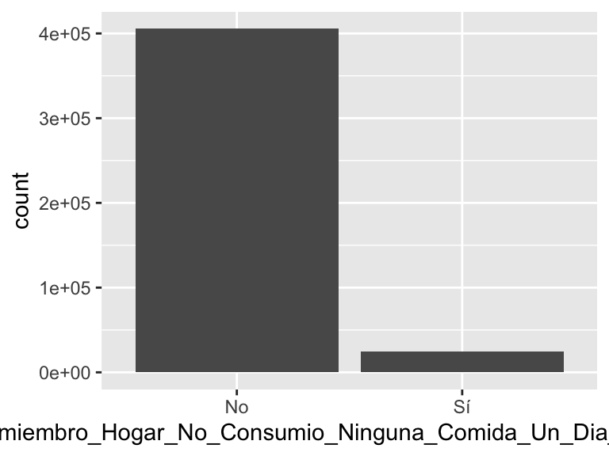

## Controles_Crecimiento_Desarrollo_p6161

| Feature | Result |
| --- | --- |
| Variable type | character |
| Number of missing obs. | 491947 (97.48 %) |
| Number of unique values | 2 |
| Mode | “Sí” |

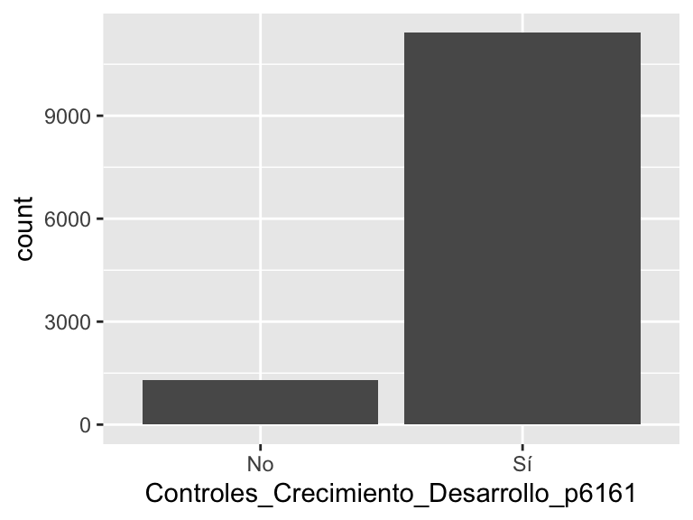

## Controles_Crecimiento_Desarrollo_numero_p6161

| Feature | Result |
| --- | --- |
| Variable type | numeric |
| Number of missing obs. | 493243 (97.74 %) |
| Number of unique values | 18 |
| Median | 2 |
| 1st and 3rd quartiles | 2; 3 |
| Min. and max. | 1; 24 |

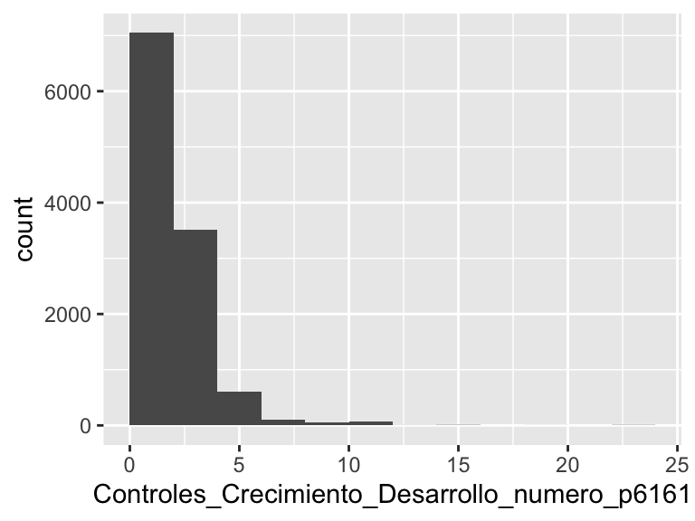

- Note that the following possible outlier values were detected: "1".

## Alfabeta_p6160

| Feature | Result |
| --- | --- |
| Variable type | character |
| Number of missing obs. | 38476 (7.62 %) |
| Number of unique values | 2 |
| Mode | “Sí” |

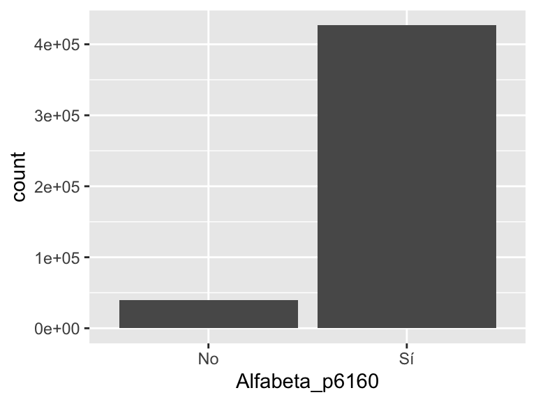

## Asiste_Educacion_p8586

| Feature | Result |
| --- | --- |
| Variable type | character |
| Number of missing obs. | 38476 (7.62 %) |
| Number of unique values | 2 |
| Mode | “No” |

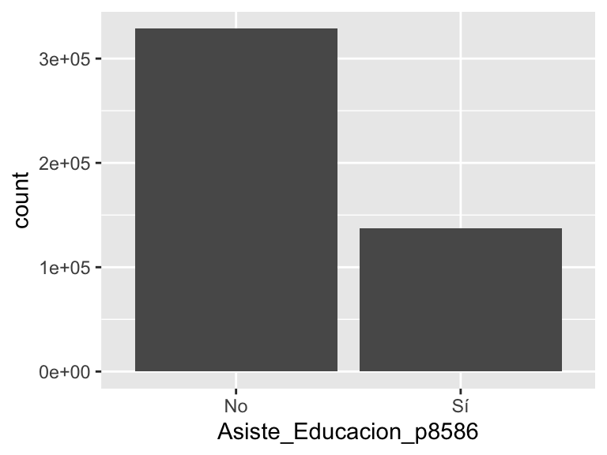